# Investigation of Potential Correlations from ARTEMIS Data

## Introduction

- What is ARTEMIS?
  - 3-instrument wonder machine
  - Important variables (NOx, Ozone)

[figure not shown]

## Purpose

- Two goals:
  - Create Shiny App to allow for quick observation and interaction with data.
  - Draw a few basic conclusions from the data.
    - Times or directions of higher NOx content.
    - Correlation between two+ variables.

## Gathering of Data

- Lab of Dr. Donohoue, Lawrence University
  - Sampling -> power issues
- Data gathered over three weeks in November outside of Alexander Gymnasium.
  - Three .csv files recording from the separate instruments

[figure not shown]

## Cleaning and Joining and Filtering, Oh My!

- Goal: input multiple .csv's to output a single dataset
- Data was gathered at unique intervals for each instrument
- Joining the data required consistency of timestamp
- We were able to group and average the data by minute
- str_sub() and summarize()

## Developing Plots

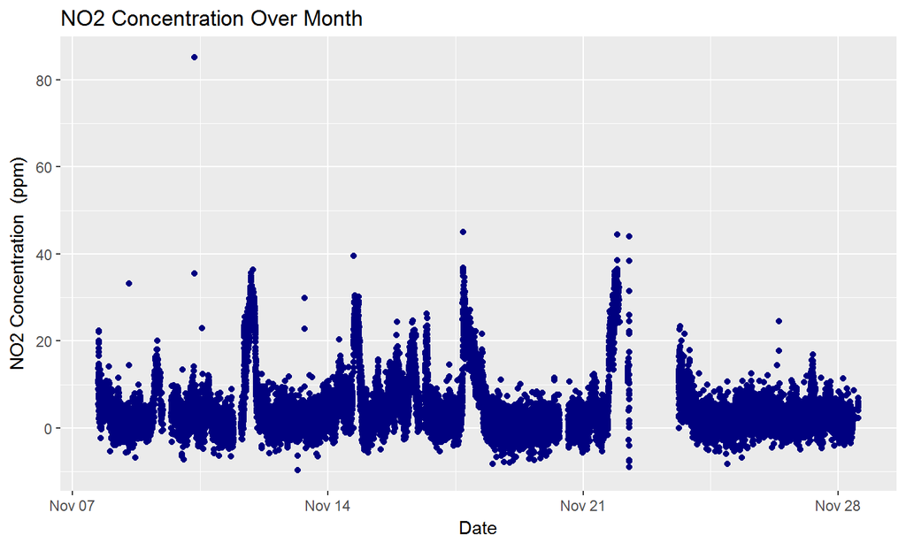

## Filtered data for better plotting

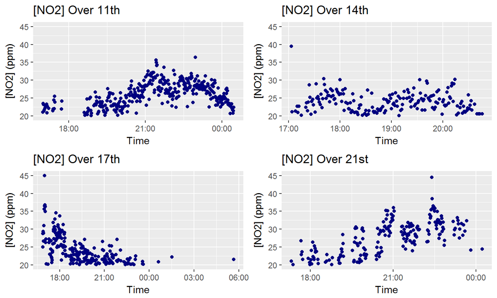

## More Plots

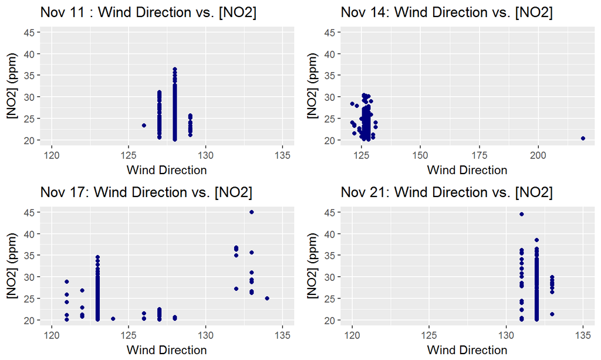

## Creation of Shiny App

- What we wanted to include:
  - Selection of x- and y-variables.
  - Smoothing/Linear Fit curves as an option.
  - Optional adjustment of scale, a.k.a. user filtering
  - Statistical information (as an option)
- What made it easier/harder

[interactive chart not shown]

## Future Usage/Development

- Increase breadth of the Shiny application:
  - Finding a way to include different, related data
  - Add further analysis of data within the application
- Combine with future ARTEMIS data

## References/Acknowledgements

- Dr. Donohoue, for data and initial interest
- Dr. Loy, coding help